# Week 2: Introduction to Likelihood Inference

PS 818 - Data Analysis with Statistical Models

Anton Strezhnev

strezhnev@wisc.edu

University of Wisconsin-Madison

September 14, 2026

## Likelihood Inference

## Previously

- Linear regression
  - “Agnostic” regression and the **Best Linear Predictor**
  - “Classical” OLS regression theory
- Key intuitions
  - Regression as a **projection** of $Y$ into the column space of $\mathbf{X}$
  - Frisch-Waugh-Lovell theorem
- Throughout, we assumed as *little* as possible about the distribution of $Y$.

## This week

- What is a **statistical model**?
- What is a **likelihood**?
- Properties of the **maximum likelihood estimator**
- How do we actually *compute* the MLE – and its standard errors?
  - This last part turns out to be much less automatic than it looks.

## Statistical models

## Defining a statistical model

- In the regression setting we tried to make as few assumptions about the data-generating process as possible.
  - Our goal is just to estimate and conduct inference on $E[Y|X]$.
- But what if we wanted to make further probabilistic statements about other quantities beyond $\beta$?
  - (e.g.) Can we provide a distribution for $Y_{n+1}$, the “next” observation given $X_{n+1}$?
  - If we’re willing to make more assumptions about the data-generating process, we can do a lot more!
- **Statistical models** specify the data-generating process in terms of *systematic* and *stochastic* components.
  - **Systematic** elements are functions of known constants and unknown *parameters*
  - **Stochastic** elements are draws from probability distributions
- We will be primarily working with *parametric* models
  - The data are assumed to come from a particular family of probability distributions
  - The “structure” of the model is fixed (the number of parameters does not grow with the size of the data).

## The linear model

- It is common to see the linear model written in its fully parametric form.
- **Stochastic**:

  $$y_i \sim \text{Normal}(\mu_i, \sigma^2)$$
- **Systematic**:

  $$\mu_i = x_i^{\prime}\beta$$
- What’s assumed to be known?
  - $\mathbf{x}$
- What’s assumed to have a particular distribution?
  - $y$
- We are interested in estimating and conducting inference on the parameters: $\beta$ and (less importantly) $\sigma^2$.

## General model notation

- We can specify a broad set of models for $y_i$ using this framework
- **Stochastic**

  $$y_i \sim f(\theta_i, \alpha)$$
- **Systematic**

  $$\theta_i = g(x_i, \beta)$$

## General model notation

- What are these quantities?
  - $y_i$ is a random variable
  - $f()$ denotes the distribution of that random variable
  - $\theta_i$ and $\alpha$ are parameters of that distribution
  - $g()$ is some function
  - $x_i$ are observed, known constants (e.g. regressors)
  - $\beta$ are parameters of interest
- Later, we will spend some time with a particular class of models called “Generalized Linear Models” where the systematic component has the form

  $$\theta_i = g(x_i^{\prime}\beta)$$

## Types of distributions

- **Normal**

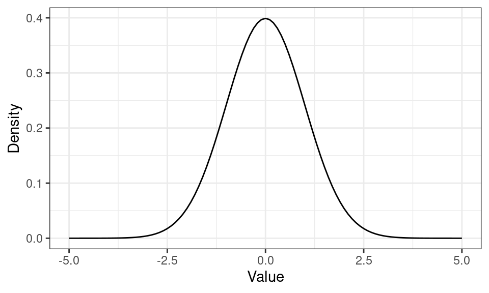

- Continuous on an unbounded support $(-\infty, \infty)$
- Two parameters: Mean $\mu$ and Variance $\sigma^2$

  $$f(x;\mu, \sigma) = \frac{1}{\sigma\sqrt{2\pi}} \exp\left\{- \frac{1}{2}\left(\frac{x - \mu}{\sigma}\right)^2 \right\}$$

## Types of distributions

- **Poisson**

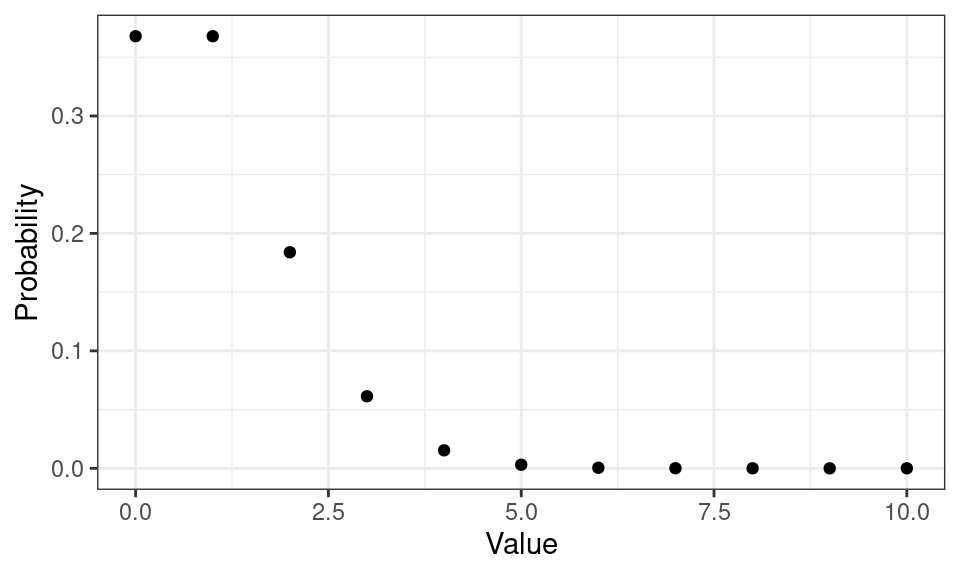

- Discrete, defined on the support of the natural numbers (positive integers + zero)
- Single parameter: Mean and Variance $\lambda$

  $$f(x; \lambda) = \frac{\lambda^x\exp\{-\lambda\}}{x!}$$

## Types of distributions

- **Binomial**

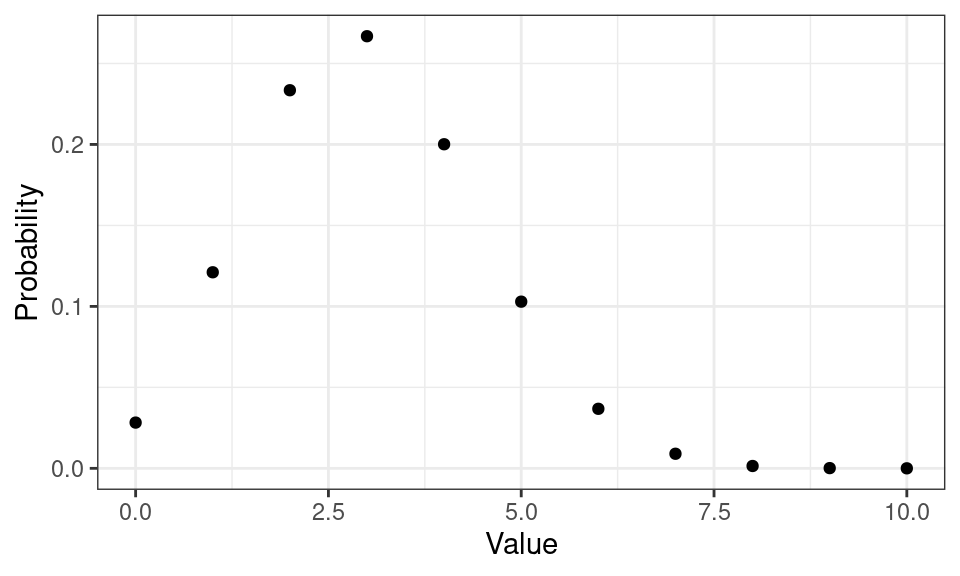

- Discrete, defined on the support of integers from $\{0, 1, 2, \dotsc, n\}$ (models the sum of repeated i.i.d. coin flips)
- Two parameters: $p$ probability of success in $n$ trials
  - Special case where $n=1$ trial is typically called the “Bernoulli”

  $$f(x; p, n) = {n \choose x} p^x(1-p)^{n-x}$$

## Likelihood inference

## Learning about the unknown

- Suppose that I want to learn about an unobserved parameter from a sample of observations.
  - I *assume* a particular statistical model for the data
  - **Example**: The linear model from earlier!
- **Frequentist** approach
  - Unobserved parameters are **fixed constants**
  - Data are **random variables**
- We want to construct an **estimator** that is a *function* of the data and which has desirable properties
  - **Consistency**: As our sample size gets larger, the estimator converges (in probability) to the target parameter.
  - **Asymptotic normality**: In large samples, the distribution of our estimator is normal (ideally with a variance we can estimate as well!)
- Can we come up with a *generic* framework that yields a “good” estimator for a large class of statistical models?

## The Likelihood Function

- Consider data $\mathbf{y} = \{y_1, y_2, \dotsc, y_n\}$ which we assume comes from a known distribution with density $f(\mathbf{y} | \theta)$ with unknown parameter $\theta$
  - $f()$ could be Bernoulli, Normal, Poisson, Gamma, Beta, etc… – in this setting it is a *known* distribution
  - $\theta$ is an *unknown* parameter that lies in some space $\Theta$ of possible values.
- The **likelihood function** is a function of $\theta$ that is evaluated at the observed values of $\mathbf{y}$

  $$\mathcal{L}(\theta| \mathbf{y}) = f(\mathbf{y} | \theta)$$
- Given some *input* $\theta$, the likelihood function returns the density of the observed data evaluated at that value.
- The likelihood function is **not** a probability density
  - a pdf is a function that takes $x$ as an input
  - a likelihood is a function that takes $\theta$ as an input

## The Likelihood Function

- The likelihood function is **not** $f(\theta | \mathbf{y})$
  - That statement doesn’t even make sense in a frequentist framework – parameters are constants
- Even when we (later) move to a *Bayesian* framework, $f(\theta | \mathbf{y}) \neq f(\mathbf{y} | \theta)$
- Remember Bayes’ Rule:

  $$f(\theta | \mathbf{y}) = \frac{f(\mathbf{y} | \theta)}{f(\mathbf{y})} \times f(\theta)$$
- Or alternatively, since $f(\mathbf{y})$ is just a normalizing constant, you’ll see this written as:

  $$\underbrace{f(\theta | \mathbf{y})}_{\text{posterior}} \propto \underbrace{f(\mathbf{y}|\theta)}_{\text{likelihood}} \times \underbrace{f(\theta)}_{\text{prior}}$$

## The Likelihood Function

- We often make the assumption that our data are **independently and identically distributed**
  - $y_i \underset{{\text{i.i.d}}}{\sim} f(y_i | \theta)$
- This allows us to factor the likelihood

  $$\mathcal{L}(\theta|\mathbf{y}) = f(\mathbf{y} | \theta) = \prod_{i=1}^n f(y_i | \theta)$$
- Since our eventual goal will be to find an *optimum* of the likelihood, we can apply any strictly increasing function to it, since that preserves the location of the maximum.
  - The main one we’ll apply is the **logarithm**
  - Why? Because logs turn annoying-to-work-with products into easier-to-work-with sums!

## Notation: sums vs. averages

- For theory reasons, you’ll see two forms of the log-likelihood
- The **total** log-likelihood

  $$\ell_n(\theta) = \sum_{i=1}^n \log f(y_i | \theta)$$
- The **average** log-likelihood

  $$\bar{\ell}_n(\theta) = \frac{1}{n}\ell_n(\theta) = \frac{1}{n}\sum_{i=1}^n \log f(y_i | \theta)$$
- These have the *same* maximizer
  - But the **average** lets us make law-of-large-numbers arguments - this will matter later on!

## Notation: Score and Hessian

- The **score** for a single observation is the gradient of its log-density with respect to $\theta$

  $$s_i(\theta) = \frac{\partial}{\partial\theta} \log f(y_i | \theta)$$
- For a $k$-dimensional $\theta$, $s_i(\theta)$ is a $k \times 1$ vector.
- The **Hessian** for a single observation is the matrix of second derivatives

  $$H_i(\theta) = \frac{\partial^2}{\partial\theta\partial\theta^{\prime}} \log f(y_i | \theta)$$

## Notation: Score and Hessian

- Summing and averaging as before:

  $$S_n(\theta) = \sum_{i=1}^n s_i(\theta) \qquad \bar{S}_n(\theta) = \frac{1}{n}\sum_{i=1}^n s_i(\theta)$$

  $$H_n(\theta) = \sum_{i=1}^n H_i(\theta) \qquad \bar{H}_n(\theta) = \frac{1}{n}\sum_{i=1}^n H_i(\theta)$$
- $S_n(\theta)$ is exactly the gradient of $\ell_n(\theta)$, and $H_n(\theta)$ its Hessian.

## MLE

- We want to come up with an estimator $\hat{\theta}$ for the parameter $\theta$
  - $\hat{\theta}$ is a function of the data (like a sample mean or OLS coefficient)
  - Is there a principled way to pick $\hat{\theta}$ that has provably “good” properties across a wide variety of models?
- The Maximum Likelihood Estimator (MLE) $\hat{\theta}$ is defined as the value of $\theta$ that maximizes the log-likelihood

  $$\hat{\theta} = \argmax_{\theta \in \Theta} \ \ell_n(\theta)$$
- Under i.i.d. observations (and regularity conditions), the MLE has some desirable properties:
  - **Consistent**: $\hat{\theta} \overset{p}{\to} \theta_0$, the true parameter
  - **Asymptotically normal**: $\sqrt{n}(\hat{\theta} - \theta_0) \overset{d}{\to} \text{Normal}\big(0, \mathcal{I}(\theta_0)^{-1}\big)$
  - **Asymptotically efficient**: its variance attains the Cramér-Rao lower bound

## The score has mean zero

- First, we’ll start with some properties of the score.
- One property that comes up frequently: evaluated at the parameter that generated the data, the score has mean zero

  $$\mathbb{E}_{\theta}\big[s_i(\theta)\big] = 0$$
- Start from the definition of the score

  $$\mathbb{E}_{\theta}\big[s_i(\theta)\big] = \int \left[\frac{\partial}{\partial\theta} \log f(y|\theta)\right] f(y|\theta) \, dy$$
- Apply the chain rule to $\log f$, then cancel $f(y|\theta)$

  $$= \int \frac{\partial}{\partial\theta} f(y|\theta) \, dy$$

## The score has mean zero

- Swap the derivative and the integral (regularity condition - we assume we’re able to do this)

  $$= \frac{\partial}{\partial\theta} \int f(y|\theta) \, dy$$
- The density integrates to one

  $$= \frac{\partial}{\partial\theta} \, 1 \; = \; 0$$

## Consistency

- By the weak law of large numbers, for each $\theta$

  $$\bar{\ell}_n(\theta) = \frac{1}{n} \sum_{i=1}^n \log f(y_i | \theta) \overset{p}{\rightarrow} \mathbb{E}_{\theta_0}[\log f(y_i | \theta)]$$
- The MLE maximizes the left-hand side, so (under regularity conditions) $\hat{\theta}$ converges to whatever maximizes $\mathbb{E}_{\theta_0}[\log f(y_i | \theta)]$
- We can show that the true parameter $\theta_0$ maximizes $\mathbb{E}_{\theta_0}[\log f(y_i | \theta)]$

## Consistency

- Consider any other value of $\theta$ and apply properties of logs

  $$\mathbb{E}_{\theta_0}[\log f(y_i | \theta)] - \mathbb{E}_{\theta_0}[\log f(y_i | \theta_0)] = \mathbb{E}_{\theta_0}\left[\log \frac{f(y_i|\theta)}{f(y_i|\theta_0)}\right]$$
- By **Jensen’s inequality** ($\log$ is concave),

  $$\mathbb{E}_{\theta_0}\left[\log \frac{f(y_i|\theta)}{f(y_i|\theta_0)}\right] \le \log \mathbb{E}_{\theta_0}\left[\frac{f(y_i|\theta)}{f(y_i|\theta_0)}\right] = \log \int f(y|\theta) \, dy = \log 1 = 0$$
- So $\mathbb{E}_{\theta_0}[\log f(y_i | \theta)] \le \mathbb{E}_{\theta_0}[\log f(y_i | \theta_0)]$ for all $\theta$
  - And we get equality at $\theta = \theta_0$: $\theta_0$ maximizes $\mathbb{E}_{\theta_0}[\log f(y_i | \theta)]$
- Therefore the MLE is consistent: $\hat{\theta} \overset{p}{\to} \theta_0$.

## Consistency

- Note a few important conditions for identification
- **Identifiability**
  - No “plateaus” in the log-likelihood.
  - Two different values of $\theta$ can’t both maximize the log-likelihood

  $$f(\cdot\,|\theta) \neq f(\cdot\,| \theta_0) \ \forall \ \theta \neq \theta_0$$
  - This is exactly what makes the inequality above **strict** aside from $\theta = \theta_0$
- **Fixed parameter space**
  - The dimensionality of $\theta$ stays fixed and does not depend on $n$
  - Violated (e.g.) in ideal point models (new legislators mean new ideal points)
- $\theta_0$ is in the **interior** of the parameter space
  - Otherwise the score need not be zero at the optimum.

## Information

- After consistency, we want the variance and asymptotic distribution of $\hat{\theta}$.
  - To do this, we need a quantity called the **Fisher information**.
- Define the **per-observation** information as the variance of the score **at the true parameter** $\theta_0$

  $$\mathcal{I}(\theta_0) = \mathbb{E}_{\theta_0}\big[s_i(\theta_0) s_i(\theta_0)^{\prime}\big]$$
- Under some further regularity conditions this equals the negative expected Hessian

  $$\mathcal{I}(\theta_0) = -\mathbb{E}_{\theta_0}\big[H_i(\theta_0)\big]$$
- **Intuitively**: captures the curvature of the log-likelihood around the truth.
  - Sharper peak $\Rightarrow$ more information $\Rightarrow$ smaller variance.

## Information

- The **total** (sample) information for $n$ i.i.d. observations is

  $$\mathcal{I}_n(\theta_0) = -\mathbb{E}_{\theta_0}\big[H_n(\theta_0)\big] = n \, \mathcal{I}(\theta_0)$$

## Asymptotic distribution

- Now we can show that the MLE is asymptotically normal.

  $$\sqrt{n}(\hat{\theta} - \theta_0) \overset{d}{\rightarrow} \text{Normal}\big(0, \mathcal{I}(\theta_0)^{-1}\big)$$
- Our first step is to take a first-order **Taylor approximation** of the score around the **true parameter** $\theta_0$, written as a function of our estimator $\hat{\theta}$

  $$\bar{S}_n(\hat{\theta}) \approx \bar{S}_n(\theta_0) + \bar{H}_n(\theta_0)(\hat{\theta} - \theta_0)$$
- Using the fact that the score is zero at the MLE

  $$0 = \bar{S}_n(\theta_0) + \bar{H}_n(\theta_0)(\hat{\theta} - \theta_0)$$
- Rearranging gives

  $$(\hat{\theta} - \theta_0) = \big[-\bar{H}_n(\theta_0)\big]^{-1}\bar{S}_n(\theta_0)$$

## Asymptotic distribution

- Multiplying by $\sqrt{n}$

  $$\sqrt{n}(\hat{\theta} - \theta_0) = \big[-\bar{H}_n(\theta_0)\big]^{-1}\big[\sqrt{n}\,\bar{S}_n(\theta_0)\big]$$
- **First**, by the law of large numbers applied to the *average* Hessian,

  $$-\bar{H}_n(\theta_0) = -\frac{1}{n} \sum_{i=1}^n H_i(\theta_0) \overset{p}{\to} -\mathbb{E}_{\theta_0}\big[H_i(\theta_0)\big] = \mathcal{I}(\theta_0)$$
- **Second**, by the central limit theorem applied to the mean-zero scores,

  $$\sqrt{n} \, \bar{S}_n(\theta_0) = \frac{1}{\sqrt{n}} \sum_{i=1}^n s_i(\theta_0) \overset{d}{\to} \text{Normal}\big(0, \, \text{Var}_{\theta_0}(s_i(\theta_0))\big) = \text{Normal}\big(0, \mathcal{I}(\theta_0)\big)$$

## Asymptotic distribution

- **Lastly**, by Slutsky’s theorem,

  $$\sqrt{n}(\hat{\theta} - \theta_0) \overset{d}{\to} \text{Normal}\big(0, \mathcal{I}(\theta_0)^{-1}\mathcal{I}(\theta_0)\mathcal{I}(\theta_0)^{-1}\big) = \text{Normal}\big(0, \mathcal{I}(\theta_0)^{-1}\big)$$
- So our large-sample approximation for the distribution of the MLE is

  $$\hat{\theta} \overset{a}{\sim} \text{Normal}\big(\theta_0, \ \mathcal{I}_n(\theta_0)^{-1}\big)$$
- Standard errors are the square roots of the diagonal of $\mathcal{I}_n(\hat{\theta})^{-1}$.
- Can another estimator do better asymptotically?
  - It turns out the answer is **no**
  - The MLE asymptotically attains the **Cramér-Rao lower bound**.

## Cramér-Rao lower bound (CRLB)

- An important result in statistics relates to the smallest possible variance that an **unbiased** estimator could reach
  - That is, if we’re not willing to accept more **bias**, how much **precision** can we get out of the data?
  - This ends up being related to the information!
- The **Cramér-Rao lower bound** on the variance of any unbiased estimator $\hat{\theta}$ of $\theta$ is

  $$\text{Var}(\hat{\theta}) \succeq \mathcal{I}_n(\theta)^{-1}$$
- We’ll focus the proof on the scalar case
  - For vector $\theta$, “$\succeq$” means the difference $\text{Var}(\hat{\theta}) - \mathcal{I}_n(\theta)^{-1}$ is positive semi-definite.

## Cramér-Rao lower bound (CRLB)

- Under **unbiasedness**

  $$\mathbb{E}_{\theta}[\hat{\theta}(\mathbf{y}) - \theta] = \int(\hat{\theta}(\mathbf{y}) - \theta) f(\mathbf{y}| \theta)d\mathbf{y} = 0$$
- Since unbiasedness holds for every value of $\theta$, differentiating with respect to $\theta$ also gives zero

  $$\frac{\partial}{\partial\theta} \int(\hat{\theta}(\mathbf{y}) - \theta) f(\mathbf{y} |\theta)d\mathbf{y} = 0$$
- Under the regularity conditions that let us exchange differentiation and integration

  $$\int \frac{\partial}{\partial\theta} \bigg[(\hat{\theta}(\mathbf{y}) - \theta) f(\mathbf{y}| \theta)\bigg]d\mathbf{y} = 0$$

## Cramér-Rao lower bound (CRLB)

- Product rule

  $$\int (\hat{\theta}(\mathbf{y}) - \theta) \frac{\partial}{\partial\theta} f(\mathbf{y}| \theta) \, d\mathbf{y} - \int f(\mathbf{y}| \theta)d\mathbf{y} = 0$$
- PDFs integrate to 1 over their support

  $$\int (\hat{\theta}(\mathbf{y}) - \theta) \frac{\partial}{\partial\theta} f(\mathbf{y}| \theta) \, d\mathbf{y} = 1$$
- The same chain rule identity as before

  $$\frac{\partial}{\partial \theta} f(\mathbf{y}| \theta) = f(\mathbf{y}| \theta) \frac{\partial}{\partial \theta} \log f(\mathbf{y}|\theta) = f(\mathbf{y}|\theta) \, S_n(\theta)$$

## Cramér-Rao lower bound (CRLB)

- Plugging back in,

  $$\int (\hat{\theta}(\mathbf{y}) - \theta) \, S_n(\theta) \, f(\mathbf{y}| \theta)d\mathbf{y} = 1$$
- By the “law of the unconscious statistician” this is just an expectation

  $$\mathbb{E}_{\theta}\big[(\hat{\theta}(\mathbf{y}) - \theta) \, S_n(\theta)\big] = 1$$
- The **Cauchy-Schwarz inequality** for expectations says that for random variables $U$ and $V$

  $$\big|\mathbb{E}[UV]\big|^2 \le \mathbb{E}[U^2]\,\mathbb{E}[V^2]$$
- Apply it with $U = \hat{\theta}(\mathbf{y}) - \theta$ and $V = S_n(\theta)$

  $$1 = \big|\mathbb{E}_\theta[U V]\big|^2 \le \mathbb{E}_{\theta}\big[(\hat{\theta}(\mathbf{y}) - \theta)^2\big] \times \mathbb{E}_{\theta}\big[S_n(\theta)^2\big]$$

## Cramér-Rao lower bound (CRLB)

- What are the pieces here?
  - $\mathbb{E}_{\theta}[(\hat{\theta}(\mathbf{y}) - \theta)^2]$ is the **mean squared error**. Because we assumed $\hat{\theta}$ is *unbiased*, MSE is the variance.
  - $\mathbb{E}_{\theta}[S_n(\theta)^2]$ is the **total information** $\mathcal{I}_n(\theta)$
- So

  $$\text{Var}(\hat{\theta}) \times \mathcal{I}_n(\theta) \ge 1 \quad \Longrightarrow \quad \text{Var}(\hat{\theta}) \ge \frac{1}{\mathcal{I}_n(\theta)}$$
- Compare this to the large-sample distribution of the MLE from earlier:

  $$\hat{\theta}_{MLE} \overset{a}{\sim} \text{Normal}\big(\theta_0, \ \mathcal{I}_n(\theta_0)^{-1}\big)$$
- The MLE attains the bound **asymptotically**.

## The Normal model

## Deriving the log-likelihood

- Let’s consider the classical **normal regression** model with homoskedastic errors

  $$y_i \sim \text{Normal}(\mu_i, \sigma^2), \qquad \mu_i = x_i^{\prime}\beta$$
- Under i.i.d. the joint density factors, and logs turn the product into a sum

  $$\ell_n(\beta, \sigma^2) = \log \prod_{i=1}^n f(y_i| \beta, \sigma^2) = \sum_{i=1}^n \log f(y_i| \beta, \sigma^2)$$
- Plug in the Normal density for each observation

  $$\ell_n(\beta, \sigma^2) = \sum_{i=1}^n \log \bigg[\frac{1}{\sigma\sqrt{2\pi}} \exp\left\{- \frac{1}{2}\left(\frac{y_i - x_i^\prime\beta}{\sigma}\right)^2 \right\}\bigg]$$
- Properties of logs – note $\log(\sigma\sqrt{2\pi}) = \log\sigma + \tfrac{1}{2}\log(2\pi)$

  $$\ell_n(\beta, \sigma^2) = \sum_{i=1}^n \left[-\log(\sigma) - \tfrac{1}{2}\log(2\pi) -\frac{1}{2}\bigg(\frac{y_i - x_i^\prime\beta}{\sigma}\bigg)^2\right]$$

## Deriving the log-likelihood

- The $\tfrac{1}{2}\log(2\pi)$ term does not depend on $\beta$ or $\sigma$, so it cannot change the location of the maximum. Ignoring it,

  $$\ell_n(\beta, \sigma^2) = -\frac{1}{2\sigma^2} \sum_{i=1}^n (y_i - x_i^\prime\beta)^2 -n\log(\sigma)$$
- And the corresponding **average** log-likelihood

  $$\bar{\ell}_n(\beta, \sigma^2) = \frac{1}{n} \sum_{i=1}^n \bigg[-\frac{1}{2\sigma^2} (y_i - x_i^\prime\beta)^2 - \log(\sigma)\bigg]$$
- What’s familiar here?
  - For **fixed** $\sigma$, maximizing $\ell_n$ over $\beta$ is the same as *minimizing* the sum of squared residuals.
  - So the MLE for $\beta$ *is* the OLS estimator!

## Deriving the score

- Let’s derive the score. The per-observation log-density, again ignoring the constant, with residuals $e_i = y_i - x_i^\prime\beta$:

  $$\log f(y_i|\beta, \sigma) = -\frac{e_i^2}{2\sigma^2} - \log(\sigma)$$
- Differentiating with respect to $\beta$ (chain rule, $\partial e_i / \partial\beta = -x_i$):

  $$\frac{\partial}{\partial\beta} \log f(y_i|\beta,\sigma) = \frac{x_i \, e_i}{\sigma^2}$$
- Differentiating with respect to $\sigma$:

  $$\frac{\partial}{\partial\sigma} \log f(y_i|\beta,\sigma) = \frac{e_i^2}{\sigma^3} - \frac{1}{\sigma}$$
- Setting the sum of the first to zero gives the OLS normal equations $\mathbf{X}^\prime\mathbf{e} = 0$
  - The second gives $\hat{\sigma}^2 = \frac{1}{n}\sum_i e_i^2$. Note the MLE is **not** the unbiased estimator of the $\sigma^2$

## Deriving the Hessian

- Differentiating once more gives the blocks of $H_n$:

  $$\frac{\partial^2 \ell_n}{\partial\beta\partial\beta^\prime} = -\frac{\mathbf{X}^\prime\mathbf{X}}{\sigma^2}, \qquad \frac{\partial^2 \ell_n}{\partial\beta \, \partial\sigma} = -\frac{2\mathbf{X}^\prime\mathbf{e}}{\sigma^3}, \qquad \frac{\partial^2 \ell_n}{\partial\sigma^2} = \frac{n}{\sigma^2} - \frac{3\sum_i e_i^2}{\sigma^4}$$
- **Evaluated at the MLE**
  - $\mathbf{X}^\prime\mathbf{e} = 0$, so the cross-derivative is exactly **zero** – $\hat\beta$ and $\hat\sigma$ are orthogonal.
  - $\sum_i e_i^2 = n\hat\sigma^2$, so the $\sigma\sigma$ entry collapses to $-2n/\hat\sigma^2$.
- So the exact Hessian at the MLE is block diagonal:

  $$H_n(\hat{\theta}) = \begin{bmatrix} -\mathbf{X}^\prime\mathbf{X}/\hat\sigma^2 & 0 \\ 0 & -2n/\hat\sigma^2 \end{bmatrix}$$
- Which gives us closed-form standard errors

  $$\widehat{\text{Var}}(\hat\beta) = \hat\sigma^2(\mathbf{X}^\prime\mathbf{X})^{-1}$$
- Our familiar regression variance-covariance matrix for $\hat{\beta}$!

## Fitting the model

- How does Clinton’s 2016 county-level vote share vary by the share of residents who are non-Hispanic white?

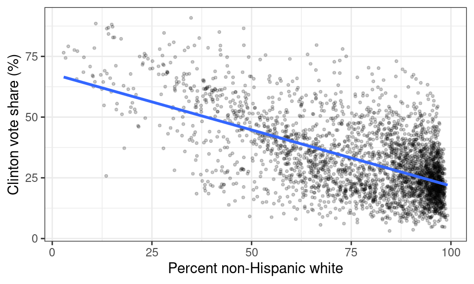

## Fitting the model

- We’ll use a **numerical optimizer** implemented in R
  - The `maxLik` package is a nice wrapper for the various optimizers built in to R
- The main routine, `maxLik`, takes a function whose first argument is the parameter vector.
  - We’ll initially give it *only* the log-likelihood, so every derivative it needs is computed **numerically**.
- First, write a function returning the log-likelihood **evaluated at each observation**

```r
norm_loglik <- function(pars, Y, X){
  beta <- pars[-length(pars)]
  sigma <- exp(pars[length(pars)])  # pars[k+1] is log(sigma)
  -(1/(2*sigma^2))*(Y - X%*%beta)^2 - log(sigma)
}
```

- For **optimization** we reparameterize $\sigma = \exp(\eta)$, so the optimizer can range over all of $\mathbb{R}$ and never has to worry about $\sigma \le 0$.

## Fitting the model

- We initialize our $\mathbf{X}$ matrix, our outcome $Y$ and some starting values for the optimizer.

```r
library(maxLik)
X_matrix <- model.matrix(voteshare ~ pctWhiteNH, data=election)
Y_vec <- election$voteshare
start_vals <- c(0, 0, 3)   # beta0, beta1, log(sigma)
```

- Then pass the function `norm_loglik` and all other arguments to `maxLik()`.
  - We’ll choose `method = "NR"` to select the **Newton-Raphson** optimizer

```r
mle_numeric <- maxLik(norm_loglik, start = start_vals, method = "NR",
                      Y = Y_vec, X = X_matrix)
round(coef(mle_numeric), 5)
```

```
[1] 67.799 -0.462  2.505
```

- Compare the point estimates to OLS:

```r
ols_est <- lm(voteshare ~ pctWhiteNH, data=election)
round(coef(ols_est), 5)
```

```
(Intercept)  pctWhiteNH
     67.808      -0.462
```

## Standard errors

- We use a **plug-in estimator** for the standard errors.
  - Calculate the Hessian at the MLE and plug it into our asymptotic variance formula we derived earlier (invert the negative hessian).

```r
vcov_numeric <- solve(-maxLik::hessian(mle_numeric))
se_numeric <- sqrt(diag(vcov_numeric))
```

- Compare these to what we get from conventional OLS standard errors

```r
comparison <- data.frame(
  term      = c("(Intercept)", "pctWhiteNH"),
  se_maxLik = se_numeric[1:2],
  se_ols    = summary(ols_est)$coefficients[,2]
)
comparison$pct_error <- 100*(comparison$se_maxLik - comparison$se_ols)/comparison$se_ols
comparison
```

```
                   term se_maxLik se_ols pct_error
(Intercept) (Intercept)   0.49869 0.9059     -44.9
pctWhiteNH   pctWhiteNH   0.00657 0.0112     -41.3
```

- These should be **identical** (aside from degrees of freedom correction in `lm`)
- Instead the slope standard error is off by about **41%**.

## The answer isn’t stable!

- Try some different starting values (vary $\log\sigma$’s initial point)

```r
se_from_start <- function(ls0, grad=NULL){
  fit <- maxLik(norm_loglik, grad=grad, start=c(0, 0, ls0), method="NR",
                Y=Y_vec, X=X_matrix)
  se <- suppressWarnings(sqrt(diag(solve(-maxLik::hessian(fit)))))
  c(beta1_hat = coef(fit)[2], SE_beta1 = se[2])
}
starts <- c(2.0, 2.303, exp(1), 2.708, 3.0)
round(t(sapply(starts, se_from_start)), 6)
```

```
     beta1_hat SE_beta1
[1,]    -0.462  0.00844
[2,]    -0.462  0.00845
[3,]    -0.462  0.00845
[4,]    -0.462      NaN
[5,]    -0.462  0.00657
```

- The **standard error** swings wildly, and in some runs the negative Hessian is not even positive definite
- The truth (from OLS) is 0.011.
- The optimizer is behaving poorly

## Numerical vs. analytical derivatives

- The **Newton-Raphson** algorithm uses the **gradient** and the **Hessian** to find the optimum iteratively.
- It can get them two ways:
- **Finite differences** (“numerical differentiation”)
  - $\frac{\partial f}{\partial\theta} \approx \frac{f(\theta + h) - f(\theta - h)}{2h}$ (done one parameter at a time)
  - Needs only the ability to *evaluate* $f$, so it works with just the likelihood as input.
  - **Approximate**, the error depends on software-selected $h$.
- **Exact derivatives**
  - Just do the calculus and pass the optimizer a function that returns the score.
  - We’ve already done this for the linear model!

## Including the analytic gradient

- We derived the score earlier. Write this as a function that returns an $N \times (k+1)$ matrix – one gradient row per observation.

```r
norm_grad <- function(pars, Y, X){
  beta <- pars[-length(pars)]
  sigma <- exp(pars[length(pars)])
  e <- as.vector(Y - X%*%beta)
  cbind(X * (e/sigma^2),        # d/d beta
        (e^2/sigma^2) - 1)      # d/d log(sigma)
}
```

## Analytic gradient: the standard errors

```r
mle_analytic <- maxLik(norm_loglik, grad = norm_grad, start = start_vals,
                       method = "NR", Y = Y_vec, X = X_matrix)
se_analytic <- sqrt(diag(solve(-maxLik::hessian(mle_analytic))))
```

```r
data.frame(
  term        = c("(Intercept)", "pctWhiteNH"),
  numeric     = se_numeric[1:2],
  analytic    = se_analytic[1:2],
  ols_truth   = summary(ols_est)$coefficients[,2]
)
```

```
                   term numeric analytic ols_truth
(Intercept) (Intercept) 0.49869   0.9056    0.9059
pctWhiteNH   pctWhiteNH 0.00657   0.0112    0.0112
```

- Supplying the gradient recovers the OLS standard errors essentially exactly.
- `maxLik` is *still* finite-differencing to get the Hessian – but now it differences the **exact** gradient - less room for numerical error.

## And now it is stable

- Across different starting values

```r
round(t(sapply(starts, se_from_start, grad = norm_grad)), 6)
```

```
     beta1_hat SE_beta1
[1,]    -0.462   0.0112
[2,]    -0.462   0.0112
[3,]    -0.462   0.0112
[4,]    -0.462   0.0112
[5,]    -0.462   0.0112
```

- The same answer from every start.

## Standardizing $Y$ and $X$

- Another solution is to make the inputs better behaved
  - Normalize $Y$ and $X$ by subtracting the mean and dividing by the standard deviation.

```r
election$voteshare_z  <- (election$voteshare  - mean(election$voteshare))/sd(election$voteshare)
election$pctWhiteNH_z <- (election$pctWhiteNH - mean(election$pctWhiteNH))/sd(election$pctWhiteNH)
X_z <- model.matrix(voteshare_z ~ pctWhiteNH_z, data=election)
Y_z <- election$voteshare_z
```

- We’ll compare the two approaches

```r
mle_z_numeric  <- maxLik(norm_loglik, start = start_vals, method="NR", Y = Y_z, X = X_z)
mle_z_analytic <- maxLik(norm_loglik, grad = norm_grad, start = start_vals,
                         method="NR", Y = Y_z, X = X_z)
```

- The discrepancy disappears

```r
se_z_numeric  <- sqrt(diag(solve(-maxLik::hessian(mle_z_numeric))))
se_z_analytic <- sqrt(diag(solve(-maxLik::hessian(mle_z_analytic))))
data.frame(
  term     = c("(Intercept)", "pctWhiteNH", "log(sigma)"),
  numeric  = se_z_numeric,
  analytic = se_z_analytic,
  pct_diff = 100*(se_z_numeric - se_z_analytic)/se_z_analytic
)
```

```
         term numeric analytic  pct_diff
1 (Intercept)  0.0144   0.0144 -0.000879
2  pctWhiteNH  0.0144   0.0144 -0.001603
3  log(sigma)  0.0127   0.0127  0.001887
```

## Getting back to interpretable units

- To get back to the units of interest, **undo** the re-scaling:

  $$\hat\beta_1^{raw} = \hat\beta_1^{z} \times \frac{s_Y}{s_X}, \qquad \widehat{\text{SE}}(\hat\beta_1^{raw}) = \widehat{\text{SE}}(\hat\beta_1^{z}) \times \frac{s_Y}{s_X}$$

```r
scale_ratio <- sd(election$voteshare)/sd(election$pctWhiteNH)
data.frame(
  quantity   = c("slope", "SE(slope)"),
  from_z     = c(coef(mle_z_analytic)[2]*scale_ratio, se_z_analytic[2]*scale_ratio),
  ols_truth  = summary(ols_est)$coefficients[2,1:2]
)
```

```
            quantity  from_z ols_truth
Estimate       slope -0.4617   -0.4617
Std. Error SE(slope)  0.0112    0.0112
```

## “Robust” standard errors

## Relaxing the information matrix equality

- Return to the asymptotic variance derivation. We had the **sandwich**

  $$\text{Var}\big(\sqrt{n}(\hat{\theta}-\theta_0)\big) \approx \underbrace{\big[-\mathbb{E}_{\theta_0}[H_i(\theta_0)]\big]^{-1}}_{\text{bread}} \underbrace{\text{Var}_{\theta_0}\big(s_i(\theta_0)\big)}_{\text{meat}} \underbrace{\big[-\mathbb{E}_{\theta_0}[H_i(\theta_0)]\big]^{-1}}_{\text{bread}}$$
- Previously we used the information matrix equality – $\text{meat} = \text{bread}^{-1} = \mathcal{I}(\theta_0)$ – to collapse this to $\mathcal{I}(\theta_0)^{-1}$.
  - That equality holds **only if the model is correctly specified**. If it isn’t, the two differ, and only the sandwich is consistent.
- Instead, we can estimate each piece separately with sample analogues:

  $$\widehat{\text{Var}}(\hat{\theta}) = \bigg[-\sum_{i=1}^n H_i(\hat\theta)\bigg]^{-1}\bigg[\sum_{i=1}^n s_i(\hat{\theta}) s_i(\hat{\theta})^{\prime}\bigg]\bigg[-\sum_{i=1}^n H_i(\hat\theta)\bigg]^{-1}$$
- Consistent under misspecification of the outcome distribution, but finite-sample properties can be poor absent corrections (e.g. $\frac{n}{n-k}$ scaling known as HC1).

## Implementing the sandwich

- `sandwich::estfun` returns the per-observation gradient

```r
grad_mat <- sandwich::estfun(mle_analytic)
dim(grad_mat)
```

```
[1] 3114    3
```

```r
round(colSums(grad_mat), 6)   # should be ~0 at the MLE
```

```
[1] -1.0e-06 -5.1e-05  3.1e-05
```

- Assembling the three pieces:

```r
bread_inv <- solve(-maxLik::hessian(mle_analytic))
meat      <- t(grad_mat) %*% grad_mat
robust_vcov <- bread_inv %*% meat %*% bread_inv
n <- nrow(election); k <- ncol(X_matrix)
```

```r
data.frame(
  term       = c("(Intercept)", "pctWhiteNH", "log(sigma)"),
  classical  = sqrt(diag(solve(-maxLik::hessian(mle_analytic)))),
  robust     = sqrt(diag(robust_vcov)),
  robust_hc1 = sqrt(diag(robust_vcov) * n/(n-k))
)
```

```
         term classical robust robust_hc1
1 (Intercept)    0.9056 1.0348     1.0351
2  pctWhiteNH    0.0112 0.0122     0.0122
3  log(sigma)    0.0127 0.0138     0.0139
```

## Conclusion

- **Statistical models**
  - Describe the data-generating process in terms of *systematic* and *stochastic* components
  - In a parametric model, we assume the data $\mathbf{y}$ come from a known *distribution* with unknown parameters $\theta$
- **Likelihood**
  - A function of $\theta$ evaluated at the observed data $\mathbf{y}$, equal to $f(\mathbf{y}|\theta)$
  - How *relatively* plausible are my observed results in a world where the true DGP parameter were $\theta$?
  - Not $f(\theta|\mathbf{y})$. That quantity only makes sense in the Bayesian context and requires a prior $f(\theta)$
- **Maximum Likelihood Estimator**
  - A *technique* for constructing a good estimator whenever we can write down a well-behaved likelihood
  - Consistency, asymptotic normality, asymptotic efficiency – all **large sample** properties

## Next week

- **More on maximum likelihood estimators**
  - Invariance, the delta method, likelihood ratio / Wald / score tests
- **How do optimizers work**
  - Newton’s method, gradient ascent/descent
- **Generalized linear models**
  - Link functions and the exponential family
- **Binary outcome models**
  - Logit and probit as likelihood models
- **Readings:** Chapters 13-14 of Gelman, Hill, and Vehtari (2020)

## References

Gelman, Andrew, Jennifer Hill, and Aki Vehtari. 2020. *Regression and Other Stories*. Cambridge: Cambridge University Press. https://avehtari.github.io/ROS-Examples/index.html.